# Capabilities Index

# Graded response model (the capabilities index)

Specifying the model with a country fixed effect, a random effects parameter that allows for freely-estimated covariances among the dimensions, and an item-specific discrimination parameter

```r
formula1 <- bf(
  y ~ 1 + country +                                # Country fixed effect
    (1 + dimension | item) + (0 + dimension | id), # Random effects terms
  disc ~ 1 + (1 | item)                            # Discrimination parameter
)
```

Retrieving prior suggestions

```r
get_prior(
  formula = formula1,
  data = d,
  family = brmsfamily("cumulative", "logit", threshold = "flexible")
)
```

```
##                 prior     class           coef group resp dpar nlpar lb ub
##                (flat)         b
##                (flat)         b  countryKosovo
##                (flat)         b countryMoldova
##                (flat)         b countryRomania
##                lkj(1)       cor
##                lkj(1)       cor                   id
##                lkj(1)       cor                 item
##  student_t(3, 0, 2.5) Intercept
##  student_t(3, 0, 2.5) Intercept              1
##  student_t(3, 0, 2.5) Intercept              2
##  student_t(3, 0, 2.5) Intercept              3
##  student_t(3, 0, 2.5) Intercept              4
##  student_t(3, 0, 2.5)        sd                                       0
##  student_t(3, 0, 2.5)        sd                   id                  0
##  student_t(3, 0, 2.5)        sd     dimension1    id                  0
##  student_t(3, 0, 2.5)        sd     dimension2    id                  0
##  student_t(3, 0, 2.5)        sd     dimension3    id                  0
##  student_t(3, 0, 2.5)        sd                 item                  0
##  student_t(3, 0, 2.5)        sd     dimension2  item                  0
##  student_t(3, 0, 2.5)        sd     dimension3  item                  0
##  student_t(3, 0, 2.5)        sd      Intercept  item                  0
##          normal(0, 1) Intercept                           disc
##  student_t(3, 0, 2.5)        sd                           disc        0
##  student_t(3, 0, 2.5)        sd                 item      disc        0
##  student_t(3, 0, 2.5)        sd      Intercept  item      disc        0
##        source
##       default
##  (vectorized)
##  (vectorized)
##  (vectorized)
##       default
##  (vectorized)
##  (vectorized)
##       default
##  (vectorized)
##  (vectorized)
##  (vectorized)
##  (vectorized)
##       default
##  (vectorized)
##  (vectorized)
##  (vectorized)
##  (vectorized)
##  (vectorized)
##  (vectorized)
##  (vectorized)
##  (vectorized)
##       default
##       default
##  (vectorized)
##  (vectorized)
```

Specifying the priors. Broad weakly informative priors are used so the data dominates the posterior estimates. These can be tightened further if the postestimation tests detect weak predictive performance.

```r
prior1 <-
  prior(lkj(1), class = "cor") +
  prior(normal(0, 5), class = "sd") +
  prior(normal(0, 5), class = "b") +
  prior(normal(0, 5), class = "Intercept") +
  prior(normal(0, 1), class = "Intercept", dpar = "disc")
```

Running the model with each chain running in parallel with the future package

```r
plan(multisession, workers = 4)

fit2 <- brm(
  formula = formula1,
  data = d,
  family = brmsfamily("cumulative", "logit", threshold = "flexible"),
  prior = prior1,
  cores = 4,
  chains = 4,
  iter = 3000,
  warmup = 1500,
  control = list(adapt_delta = 0.99, max_treedepth = 15),
  save_pars = save_pars(all = TRUE),
  future = TRUE,
  file = "01-ruwell-FINAL1.rds"
)
plan(sequential)
```

Generating model summaries

```r
summary(fit2)
```

```
##  Family: cumulative
##   Links: mu = logit; disc = log
## Formula: y ~ 1 + country + (1 + dimension | item) + (0 + dimension | id)
##          disc ~ 1 + (1 | item)
##    Data: d (Number of observations: 24468)
##   Draws: 4 chains, each with iter = 3000; warmup = 1500; thin = 1;
##          total post-warmup draws = 6000
##
## Multilevel Hyperparameters:
## ~id (Number of levels: 2039)
##                            Estimate Est.Error l-95% CI u-95% CI Rhat Bulk_ESS
## sd(dimension1)                 4.26      0.92     2.62     6.23 1.00      927
## sd(dimension2)                 1.87      0.41     1.15     2.75 1.00      943
## sd(dimension3)                 4.15      0.90     2.56     6.07 1.00      930
## cor(dimension1,dimension2)     0.26      0.04     0.18     0.34 1.00     3718
## cor(dimension1,dimension3)     0.45      0.03     0.40     0.50 1.00     2075
## cor(dimension2,dimension3)     0.48      0.04     0.40     0.56 1.01      718
##                            Tail_ESS
## sd(dimension1)                 1447
## sd(dimension2)                 1611
## sd(dimension3)                 1632
## cor(dimension1,dimension2)     4471
## cor(dimension1,dimension3)     3180
## cor(dimension2,dimension3)     1213
##
## ~item (Number of levels: 12)
##                            Estimate Est.Error l-95% CI u-95% CI Rhat Bulk_ESS
## sd(Intercept)                  2.31      1.30     0.60     5.62 1.00     1051
## sd(dimension2)                 3.60      2.03     0.28     8.29 1.00     1816
## sd(dimension3)                 2.17      1.74     0.07     6.45 1.00     2366
## sd(disc_Intercept)             0.32      0.08     0.21     0.53 1.00     1662
## cor(Intercept,dimension2)      0.01      0.48    -0.85     0.87 1.00     3009
## cor(Intercept,dimension3)     -0.14      0.50    -0.91     0.83 1.00     5909
## cor(dimension2,dimension3)     0.01      0.51    -0.89     0.89 1.00     5553
##                            Tail_ESS
## sd(Intercept)                  2183
## sd(dimension2)                 2117
## sd(dimension3)                 2481
## sd(disc_Intercept)             2738
## cor(Intercept,dimension2)      3010
## cor(Intercept,dimension3)      4300
## cor(dimension2,dimension3)     4907
##
## Regression Coefficients:
##                Estimate Est.Error l-95% CI u-95% CI Rhat Bulk_ESS Tail_ESS
## Intercept[1]     -11.22      2.28   -15.95    -7.09 1.00     1239     2189
## Intercept[2]      -6.70      1.49    -9.76    -3.99 1.00     1635     2858
## Intercept[3]      -3.27      1.11    -5.39    -1.03 1.00     2096     3172
## Intercept[4]       2.73      1.44     0.70     6.15 1.00      995     2195
## disc_Intercept    -0.81      0.24    -1.25    -0.32 1.00      911     1703
## countryKosovo      3.02      0.67     1.84     4.47 1.00      954     1689
## countryMoldova    -1.59      0.39    -2.42    -0.93 1.00     1049     1919
## countryRomania    -0.16      0.17    -0.51     0.15 1.00     2487     3002
##
## Draws were sampled using sampling(NUTS). For each parameter, Bulk_ESS
## and Tail_ESS are effective sample size measures, and Rhat is the potential
## scale reduction factor on split chains (at convergence, Rhat = 1).
```

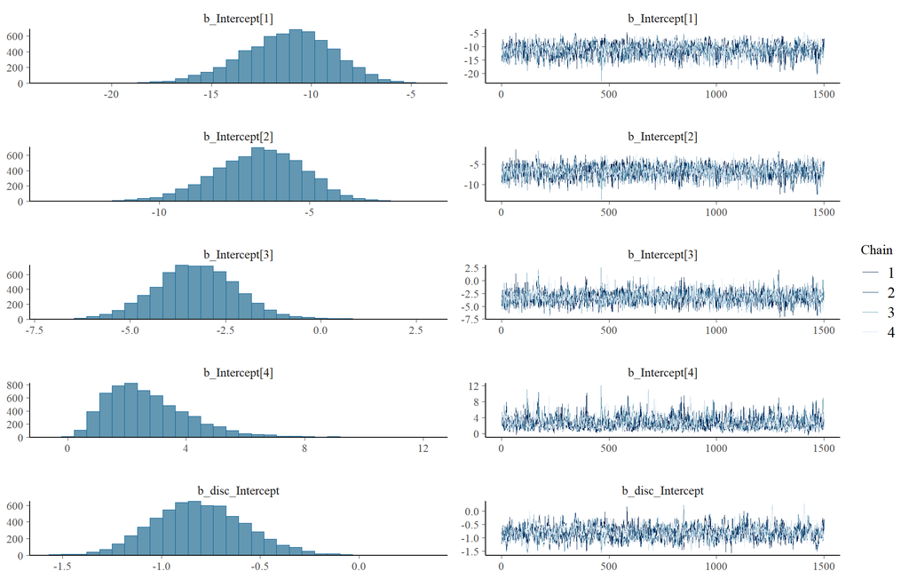

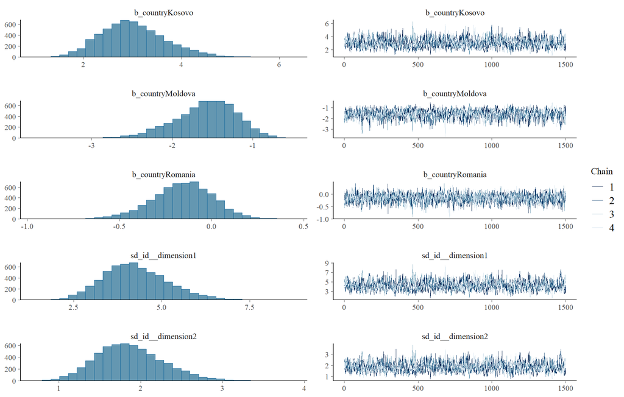

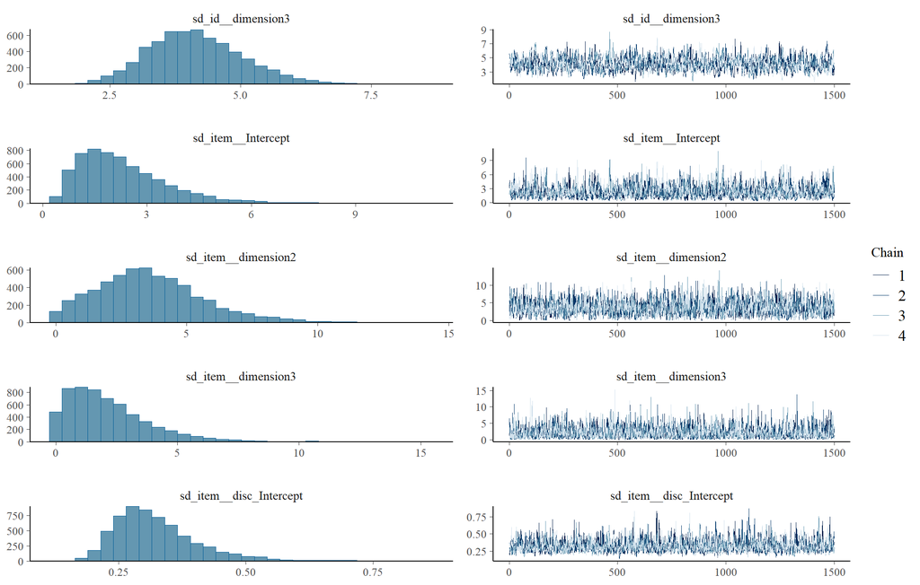

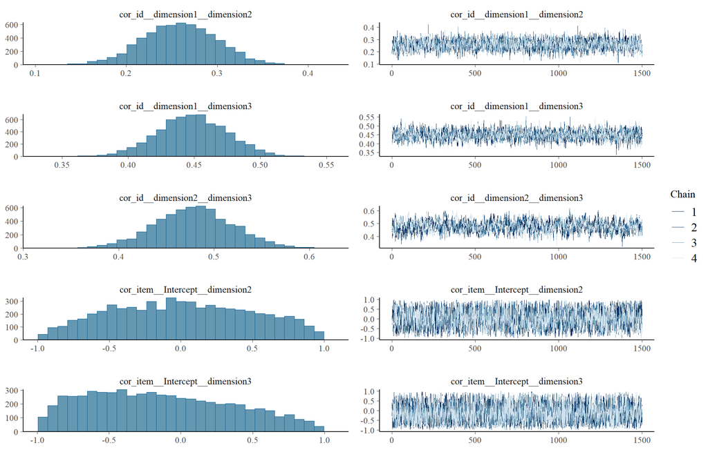

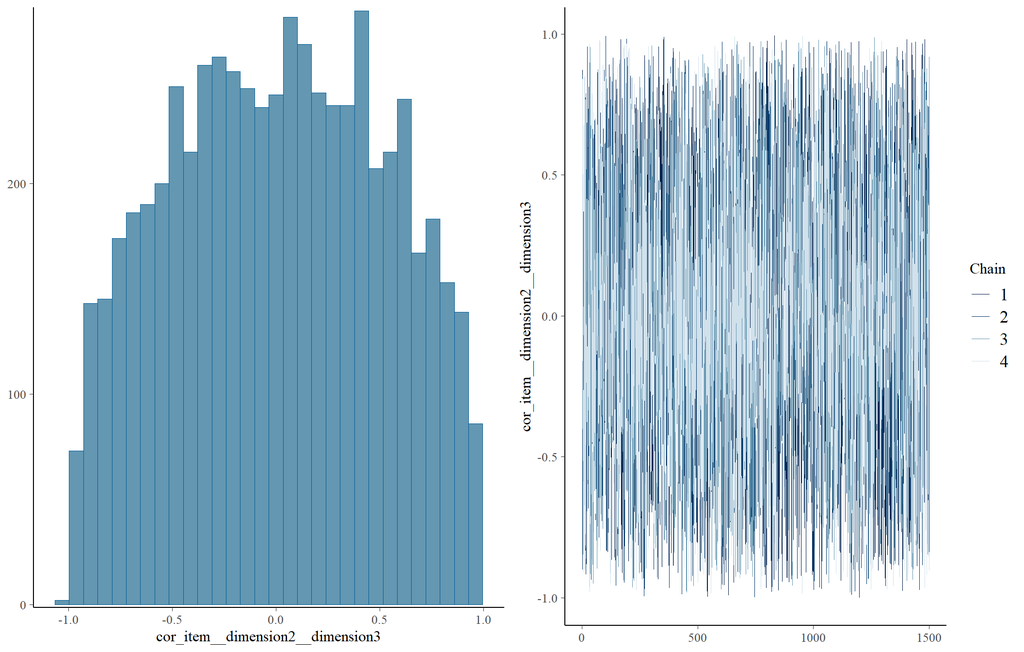

```r
fitplots <- plot(fit2)
```

```r
pdf("plot1-diagnostics.pdf", width = 11, height = 8)
gridExtra::grid.arrange(grobs = fitplots)
dev.off()
```

# Postestimation testing

The following section conducts all postestimation testing. The tests include a k-folds cross-validation test using 4 folds with the data parsed randomly by country, and three posterior predictive checks.

## K-folds test

The next block of code is an ifelse function that first checks if the test has already been conducted and saved. If so, it skips the testing function to save computation time.

```r
if (file.exists("fold_test.rds")) {
  message("Results file found.")
  folds <- readRDS("fold_test.rds")
} else {
  message("Running k-fold test. Sit back and relax...")

  # Extracting the exact data used in the model
  d_model <- fit2$data
  message("Using model data with ", nrow(d_model), " observations")

  # Assigning stratified individual-level folds
  individuals <- d_model %>%
    select(id, country) %>%
    distinct()

  fold_assignment <- individuals %>%
    group_by(country) %>%
    mutate(fold = sample(rep(1:4, length.out = n()))) %>%
    ungroup() %>%
    select(id, fold)

  d_model <- d_model %>%
    left_join(fold_assignment, by = "id")

  fold_vector <- d_model$fold
  message("Length of fold vector: ", length(fold_vector))

  # Running test in parallel sessions
  plan(multisession, workers = 4)
  folds <- kfold(fit2, folds = fold_vector, chains = 1, save_fits = T)
  plan(sequential)

  saveRDS(folds, "fold_test.rds")
  message("Results saved to dat folder")
}
```

```
## Running k-fold test. Sit back and relax...
```

```
## Using model data with 24468 observations
```

```
## Length of fold vector: 24468
```

```
## Setting 'K' to the number of folds (4)
```

```
## Fitting model 1 out of 4
```

```
## Fitting model 2 out of 4
```

```
## Fitting model 3 out of 4
```

```
## Fitting model 4 out of 4
```

```
## Results saved to dat folder
```

Extracting the test metrics

```r
estimates <- folds$estimates
rownames(estimates)
```

```
## [1] "elpd_kfold" "p_kfold"    "kfoldic"
```

Generating the metrics for exporting to the paper

```r
elpd_kfold <- estimates["elpd_kfold", "Estimate"]
se_elpd_kfold <- estimates["elpd_kfold", "SE"]
kfoldic <- estimates["kfoldic", "Estimate"]
se_kfoldic <- estimates["kfoldic", "SE"]
```

Saving all metrics to a data frame

```r
fold_results <- data.frame(
  Metric = c("ELPD", "ELPD SE", "KfoldIC", "KfoldIC SE"),
  Value = c(elpd_kfold, se_elpd_kfold, kfoldic, se_kfoldic)
)
```

Converting and exporting the metrics to a LaTeX table

```r
lat_tab2 <- xtable(fold_results,
                   caption = "K-folds cross-validation results",
                   label = "tab:kfold")
print(lat_tab2,
      file = "kfold_results.tex",
      include.rownames = FALSE,
      floating = TRUE,
      table.placement = "htbp",
      add.to.row = addtorow)
```

## Posterior predictive checks

Bars chart to compare the predicted vs observed response frequencies of each category

```r
plot2 <- pp_check(fit2, type = "bars", ndraws = 100) +
          labs(title = "Posterior predictive check (bars)")

ggsave("plot2-ppc-bars.pdf",
       plot = plot2, width = 9, height = 6)
```

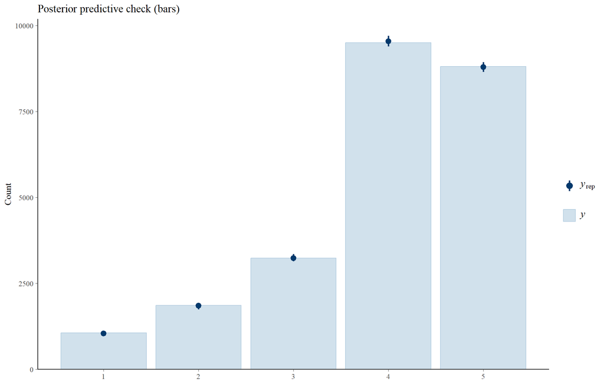

```r
print(plot2)
```

The empirical cumulative distribution function

```r
plot3 <- pp_check(fit2, type = "ecdf_overlay", ndraws = 100) +
          labs(title = "Posterior predictive check (ECDF)")

ggsave("plot3-ppc-ecdf.pdf",
       plot = plot3, width = 9, height = 6)
```

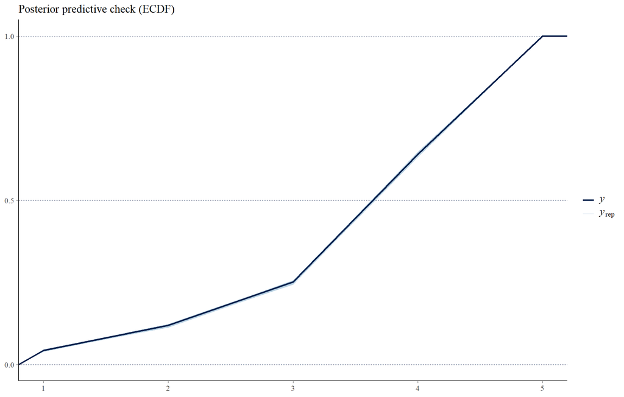

```r
print(plot3)
```

Plotting the predicted vs observed means and standard deviations

```r
plot4 <- pp_check(fit2,
          type = "stat_2d",
          stat = c("mean", "sd"),
          ndraws = 1000) +
         labs(title = "Posterior predictive check (2d stat)")

ggsave("plot4-ppc-2d.pdf",
       plot = plot4, width = 9, height = 6)
```

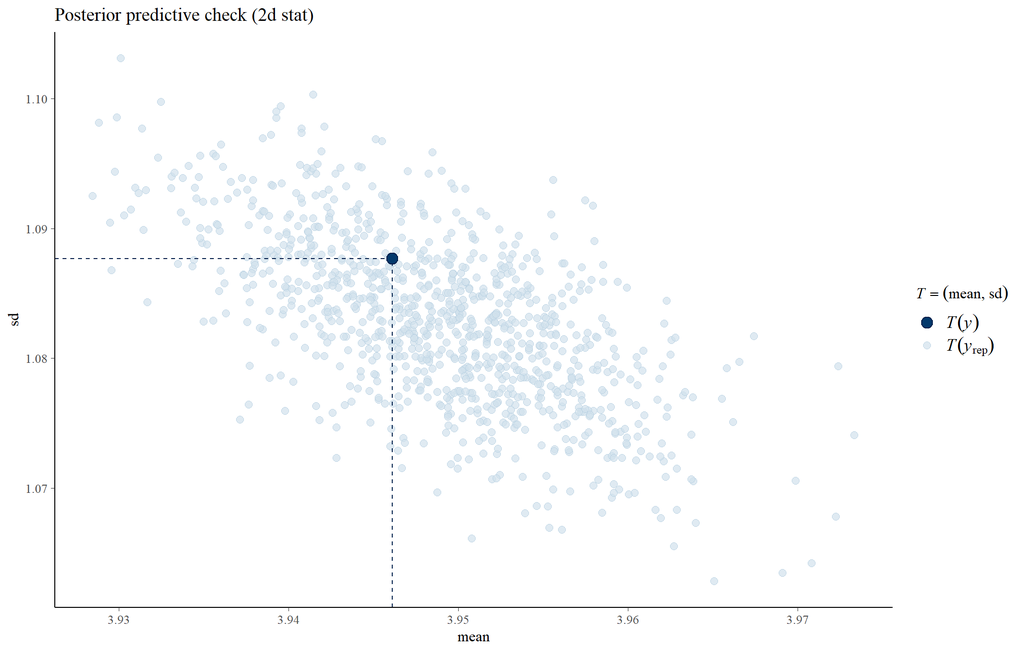

```r
print(plot4)
```

# GRM results

This section produces the plots used for the paper. This includes the easiness and discrimination parameter estimates, the MCMC draws of the fixed effect for the country covariate, and the predicted probabilities by country

## Easiness and discrimination parameters

Extracting the random effects. This object contains all random effects, and is additionally used to extract the latent traits for the auxiliary regressions

```r
ranef1 <- ranef(fit2)
str(ranef1)
```

```
## List of 2
##  $ id  : num [1:2039, 1:4, 1:3] -1.49 2.08 -3.1 1.44 0.38 ...
##   ..- attr(*, "dimnames")=List of 3
##   .. ..$ : chr [1:2039] "1001" "1002" "1003" "1004" ...
##   .. ..$ : chr [1:4] "Estimate" "Est.Error" "Q2.5" "Q97.5"
##   .. ..$ : chr [1:3] "dimension1" "dimension2" "dimension3"
##  $ item: num [1:12, 1:4, 1:4] 2.523 0.106 -0.998 0.06 0.882 ...
##   ..- attr(*, "dimnames")=List of 3
##   .. ..$ : chr [1:12] "1" "2" "3" "4" ...
##   .. ..$ : chr [1:4] "Estimate" "Est.Error" "Q2.5" "Q97.5"
##   .. ..$ : chr [1:4] "Intercept" "dimension2" "dimension3" "disc_Intercept"
```

Estimating discrimination parameter

```r
alpha <- ranef1$item[, , "disc_Intercept"] %>%
  exp() %>%
  as_tibble() %>%
  rownames_to_column()
```

Estimating easiness parameter

```r
beta <- ranef1$item[, , "Intercept"] %>%
  as_tibble() %>%
  rownames_to_column()
```

Combining parameters to one plot

```r
plot6 <- bind_rows(beta, alpha, .id = "nlpar") %>%
  rename(item = "rowname") %>%
  mutate(item = as.numeric(item)) %>%
  mutate(nlpar = factor(nlpar, labels = c("Easiness", "Discrimination"))) %>%
  ggplot(aes(item, Estimate, ymin = Q2.5, ymax = Q97.5)) +
  facet_wrap("nlpar", scales = "free_x") +
  geom_pointrange() +
  coord_flip() +
  labs(x = "") +
  scale_x_discrete(limits = 1:12, labels = item_labels)
ggsave("plot6-easidisc.pdf",
       plot = plot6, width = 9, height = 6)
```

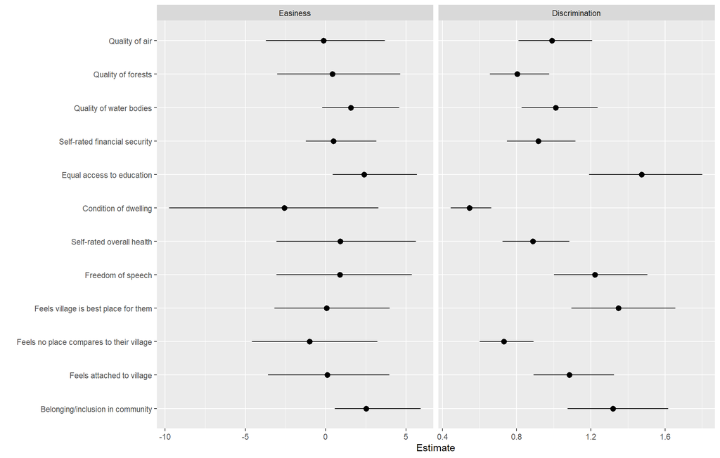

```r
print(plot6)
```

## MCMC draws of the country covariate

Extracting posterior draws

```r
posterior <- as.array(fit2)

dim(posterior)
```

```
## [1]  1500     4 12376
```

Plotting the draws by each value of country

```r
plot7 <- mcmc_areas(
          posterior,
          pars = c("b_countryKosovo", "b_countryMoldova", "b_countryRomania"),
          prob = 0.8,         # 80% inner intervals
          prob_outer = 0.95,  # 95% outer intervals
          point_est = "mean"
         ) +
        scale_y_discrete(labels = c("b_countryKosovo" = "Kosovo",
                                    "b_countryMoldova" = "Moldova",
                                    "b_countryRomania" = "Romania")) +
        labs(title = "Posterior Intervals for Country Effects",
          x = "Estimate",
          y = "Country")
ggsave("plot7-mcmc-country.pdf",
       plot = plot7, width = 9, height = 6)
```

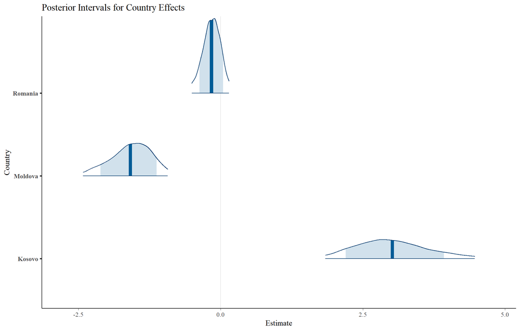

```r
print(plot7)
```

## Predicted probabilities by country

Generating the conditional effects plot

```r
plot8 <- plot(
  conditional_effects(
    fit2,
    re_formula = NULL,
    categorical = TRUE,
    prob = 0.8,
    effect = "country"
  ),
  plot = FALSE)[[1]] +
  theme_minimal() +
  labs(
    title = "Predicted Probabilities by Country",
    x = "",
    y = "Predicted Probability"
  )

ggsave("plot8-predprobs-country.pdf",
       plot = plot8, width = 9, height = 6)
```

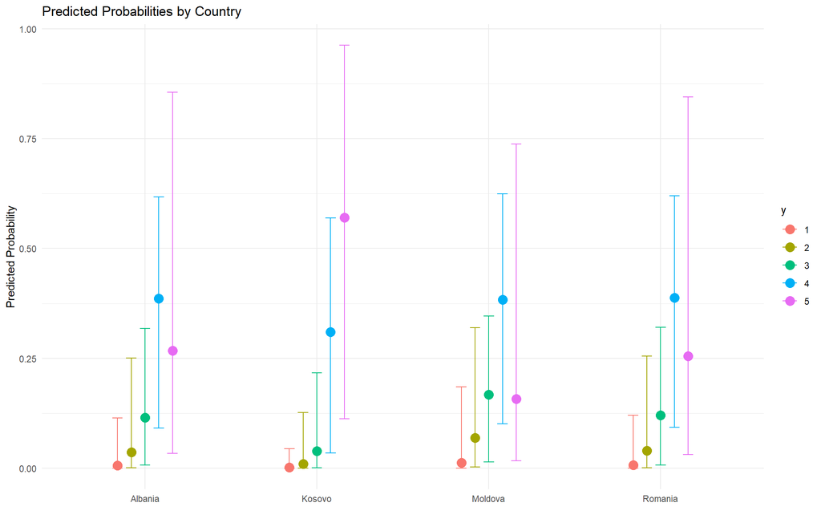

```r
print(plot8)
```

# Auxiliary regressions (latent trait models)

## Data prep

Extracting the latent traits into a second data set

```r
d2 <- d %>%
  select(id, all_of(covariates)) %>%
  distinct() %>%  # Keep only one row per person
  mutate(
    # Dimension-specific random effects
    theta_dim1 = ranef1$id[as.character(id), "Estimate", "dimension1"],
    theta_dim2 = ranef1$id[as.character(id), "Estimate", "dimension2"],
    theta_dim3 = ranef1$id[as.character(id), "Estimate", "dimension3"],
    # Standard errors
    se_dim1 = ranef1$id[as.character(id), "Est.Error", "dimension1"],
    se_dim2 = ranef1$id[as.character(id), "Est.Error", "dimension2"],
    se_dim3 = ranef1$id[as.character(id), "Est.Error", "dimension3"]
  )
```

Checking extraction results

```r
head(d2)
```

```
## # A tibble: 6 × 10
##   id    country   age female theta_dim1 theta_dim2 theta_dim3 se_dim1 se_dim2
##   <fct> <fct>   <dbl> <fct>       <dbl>      <dbl>      <dbl>   <dbl>   <dbl>
## 1 1001  Albania    68 1          -1.49     -0.0680       1.43    1.95    1.33
## 2 1002  Albania    75 1           2.08     -1.56         1.41    2.02    1.45
## 3 1003  Albania    64 0          -3.10     -0.121       -1.68    1.92    1.36
## 4 1004  Albania    69 1           1.44      1.53         5.71    1.87    1.52
## 5 1007  Albania    52 0           0.380     1.47         5.55    1.77    1.39
## 6 1008  Albania    55 1           0.806     0.525        1.87    1.88    1.46
## # ℹ 1 more variable: se_dim3 <dbl>
```

```r
nrow(d2)
```

```
## [1] 2039
```

## Specifying the regression models

Social dimension

```r
formula2 <- bf(
  theta_dim1 | se(se_dim1, sigma = TRUE) ~
    country + s(age, by = country, bs = "tp")
)
```

Personal dimension

```r
formula3 <- bf(
  theta_dim2 | se(se_dim2, sigma = TRUE) ~
    country + s(age, by = country, bs = "tp")
)
```

Environmental dimension

```r
formula4 <- bf(
  theta_dim3 | se(se_dim3, sigma = TRUE) ~
    country + s(age, by = country, bs = "tp")
)
```

## Establishing a global prior function

Checking suggested priors

```r
get_prior(
  formula = formula2,
  data = d2,
  family = brmsfamily("gaussian")
)
```

```
##                    prior     class                            coef group resp
##                   (flat)         b
##                   (flat)         b                   countryKosovo
##                   (flat)         b                  countryMoldova
##                   (flat)         b                  countryRomania
##                   (flat)         b           sage:countryAlbania_1
##                   (flat)         b            sage:countryKosovo_1
##                   (flat)         b           sage:countryMoldova_1
##                   (flat)         b           sage:countryRomania_1
##  student_t(3, -0.4, 3.8) Intercept
##     student_t(3, 0, 3.8)       sds
##     student_t(3, 0, 3.8)       sds s(age, by = country, bs = "tp")
##     student_t(3, 0, 3.8)     sigma
##  dpar nlpar lb ub       source
##                        default
##                   (vectorized)
##                   (vectorized)
##                   (vectorized)
##                   (vectorized)
##                   (vectorized)
##                   (vectorized)
##                   (vectorized)
##                        default
##              0         default
##              0    (vectorized)
##              0         default
```

Setting weakly informative priors. This function will work for all three auxiliary regressions.

```r
prior2 <- c(
  prior(normal(0, 5), class = "b"),
  prior(normal(0, 5), class = "sds"),
  prior(normal(0, 5), class = "Intercept"),
  prior(normal(0, 5), class = "sigma")
)
```

## Fitting the models

Social model

```r
fit3 <- brm(
  formula = formula2,
  data = d2,
  family = brmsfamily("gaussian"),
  prior = prior2,
  chains = 4,
  iter = 4000,
  warmup = 2000,
  control = list(adapt_delta = 0.99),
  cores = parallel::detectCores(),
  file = "01-ruwell-FINAL2.rds"
)
```

Personal model

```r
fit4 <- brm(
  formula = formula3,
  data = d2,
  family = brmsfamily("gaussian"),
  prior = prior2,
  chains = 4,
  iter = 4000,
  warmup = 2000,
  control = list(adapt_delta = 0.99),
  cores = parallel::detectCores(),
  file = "01-ruwell-FINAL3.rds"
)
```

Environmental model

```r
fit5 <- brm(
  formula = formula4,
  data = d2,
  family = brmsfamily("gaussian"),
  prior = prior2,
  chains = 4,
  iter = 4000,
  warmup = 2000,
  control = list(adapt_delta = 0.99),
  cores = parallel::detectCores(),
  file = "01-ruwell-FINAL4.rds"
)
```

Model summaries to check fits

```r
summary(fit3)  # Social
```

```
##  Family: gaussian
##   Links: mu = identity; sigma = identity
## Formula: theta_dim1 | se(se_dim1, sigma = TRUE) ~ country + s(age, by = country, bs = "tp")
##    Data: d2 (Number of observations: 2039)
##   Draws: 4 chains, each with iter = 4000; warmup = 2000; thin = 1;
##          total post-warmup draws = 8000
##
## Smoothing Spline Hyperparameters:
##                           Estimate Est.Error l-95% CI u-95% CI Rhat Bulk_ESS
## sds(sagecountryAlbania_1)     2.65      1.71     0.34     6.89 1.00     2553
## sds(sagecountryKosovo_1)      3.25      1.44     1.28     6.93 1.00     5030
## sds(sagecountryMoldova_1)     1.52      1.39     0.06     5.28 1.00     3132
## sds(sagecountryRomania_1)     7.03      3.42     0.64    14.00 1.00     1527
##                           Tail_ESS
## sds(sagecountryAlbania_1)     2870
## sds(sagecountryKosovo_1)      5105
## sds(sagecountryMoldova_1)     3776
## sds(sagecountryRomania_1)     1224
##
## Regression Coefficients:
##                       Estimate Est.Error l-95% CI u-95% CI Rhat Bulk_ESS
## Intercept                -0.90      0.13    -1.16    -0.65 1.00     8929
## countryKosovo             0.07      0.19    -0.30     0.44 1.00     9439
## countryMoldova            2.45      0.19     2.08     2.82 1.00     9359
## countryRomania            0.11      0.21    -0.30     0.53 1.00     5032
## sage:countryAlbania_1     5.28      3.52    -2.21    12.15 1.00     7821
## sage:countryKosovo_1      2.30      4.04    -6.02     9.93 1.00     7395
## sage:countryMoldova_1     2.76      2.95    -4.28     7.62 1.00     5971
## sage:countryRomania_1     4.31      4.72    -5.33    13.54 1.00     7246
##                       Tail_ESS
## Intercept                 5884
## countryKosovo             6917
## countryMoldova            6467
## countryRomania            5718
## sage:countryAlbania_1     5278
## sage:countryKosovo_1      5956
## sage:countryMoldova_1     6229
## sage:countryRomania_1     5998
##
## Further Distributional Parameters:
##       Estimate Est.Error l-95% CI u-95% CI Rhat Bulk_ESS Tail_ESS
## sigma     1.83      0.08     1.68     1.99 1.00    13345     5369
##
## Draws were sampled using sampling(NUTS). For each parameter, Bulk_ESS
## and Tail_ESS are effective sample size measures, and Rhat is the potential
## scale reduction factor on split chains (at convergence, Rhat = 1).
```

```r
summary(fit4)  # Personal
```

```
##  Family: gaussian
##   Links: mu = identity; sigma = identity
## Formula: theta_dim2 | se(se_dim2, sigma = TRUE) ~ country + s(age, by = country, bs = "tp")
##    Data: d2 (Number of observations: 2039)
##   Draws: 4 chains, each with iter = 4000; warmup = 2000; thin = 1;
##          total post-warmup draws = 8000
##
## Smoothing Spline Hyperparameters:
##                           Estimate Est.Error l-95% CI u-95% CI Rhat Bulk_ESS
## sds(sagecountryAlbania_1)     0.91      0.88     0.03     3.22 1.00     2423
## sds(sagecountryKosovo_1)      1.50      0.88     0.43     3.82 1.00     4028
## sds(sagecountryMoldova_1)     1.08      0.81     0.08     3.15 1.00     2820
## sds(sagecountryRomania_1)     0.93      1.02     0.02     3.84 1.00     2663
##                           Tail_ESS
## sds(sagecountryAlbania_1)     4100
## sds(sagecountryKosovo_1)      4603
## sds(sagecountryMoldova_1)     2235
## sds(sagecountryRomania_1)     3401
##
## Regression Coefficients:
##                       Estimate Est.Error l-95% CI u-95% CI Rhat Bulk_ESS
## Intercept                 0.18      0.07     0.05     0.31 1.00     6618
## countryKosovo            -0.26      0.09    -0.44    -0.07 1.00     7445
## countryMoldova           -0.37      0.10    -0.56    -0.18 1.00     7648
## countryRomania           -0.20      0.10    -0.38    -0.01 1.00     7394
## sage:countryAlbania_1    -2.08      1.95    -6.45     1.73 1.00     4065
## sage:countryKosovo_1     -0.76      2.62    -5.97     4.69 1.00     4821
## sage:countryMoldova_1    -1.57      2.14    -6.13     2.78 1.00     5119
## sage:countryRomania_1    -0.03      2.25    -3.92     5.56 1.00     4022
##                       Tail_ESS
## Intercept                 6060
## countryKosovo             6256
## countryMoldova            6513
## countryRomania            6155
## sage:countryAlbania_1     3525
## sage:countryKosovo_1      5450
## sage:countryMoldova_1     4620
## sage:countryRomania_1     4220
##
## Further Distributional Parameters:
##       Estimate Est.Error l-95% CI u-95% CI Rhat Bulk_ESS Tail_ESS
## sigma     0.04      0.03     0.00     0.13 1.00     6751     2852
##
## Draws were sampled using sampling(NUTS). For each parameter, Bulk_ESS
## and Tail_ESS are effective sample size measures, and Rhat is the potential
## scale reduction factor on split chains (at convergence, Rhat = 1).
```

```r
summary(fit5)  # Environmental
```

```
##  Family: gaussian
##   Links: mu = identity; sigma = identity
## Formula: theta_dim3 | se(se_dim3, sigma = TRUE) ~ country + s(age, by = country, bs = "tp")
##    Data: d2 (Number of observations: 2039)
##   Draws: 4 chains, each with iter = 4000; warmup = 2000; thin = 1;
##          total post-warmup draws = 8000
##
## Smoothing Spline Hyperparameters:
##                           Estimate Est.Error l-95% CI u-95% CI Rhat Bulk_ESS
## sds(sagecountryAlbania_1)     1.18      1.14     0.04     4.30 1.00     2713
## sds(sagecountryKosovo_1)      3.15      1.41     1.22     6.70 1.00     3829
## sds(sagecountryMoldova_1)     1.76      1.37     0.08     5.30 1.00     2290
## sds(sagecountryRomania_1)     1.70      1.62     0.06     6.03 1.00     2841
##                           Tail_ESS
## sds(sagecountryAlbania_1)     2927
## sds(sagecountryKosovo_1)      5308
## sds(sagecountryMoldova_1)     2388
## sds(sagecountryRomania_1)     4511
##
## Regression Coefficients:
##                       Estimate Est.Error l-95% CI u-95% CI Rhat Bulk_ESS
## Intercept                 0.67      0.14     0.40     0.95 1.00     5726
## countryKosovo            -1.99      0.19    -2.37    -1.62 1.00     6695
## countryMoldova           -0.71      0.20    -1.10    -0.32 1.00     6658
## countryRomania           -0.79      0.20    -1.18    -0.40 1.00     5922
## sage:countryAlbania_1     1.48      2.44    -3.94     6.59 1.00     3860
## sage:countryKosovo_1      0.16      3.89    -7.70     7.73 1.00     5416
## sage:countryMoldova_1    -0.05      3.01    -6.61     5.71 1.00     4703
## sage:countryRomania_1     2.68      2.98    -3.35     9.22 1.00     4176
##                       Tail_ESS
## Intercept                 5684
## countryKosovo             6426
## countryMoldova            5753
## countryRomania            6040
## sage:countryAlbania_1     3676
## sage:countryKosovo_1      5457
## sage:countryMoldova_1     5543
## sage:countryRomania_1     4321
##
## Further Distributional Parameters:
##       Estimate Est.Error l-95% CI u-95% CI Rhat Bulk_ESS Tail_ESS
## sigma     1.86      0.08     1.69     2.02 1.00     9770     5796
##
## Draws were sampled using sampling(NUTS). For each parameter, Bulk_ESS
## and Tail_ESS are effective sample size measures, and Rhat is the potential
## scale reduction factor on split chains (at convergence, Rhat = 1).
```

# Auxiliary regression results

Social dimension

```r
plot9 <- plot(
  conditional_effects(
    fit3,
    effects = "age:country",
    robust = TRUE
  ),
  plot = FALSE
)[[1]] +
  theme_minimal() +
  labs(
    title = expression(
      paste(theta, " by Age and Country, Social Dimension")),
    x = "Age",
    y = expression(theta),
    color = "Country",
    fill = "Country"
  )

ggsave("plot9-theta-social.pdf",
       plot = plot9, width = 9, height = 6)
```

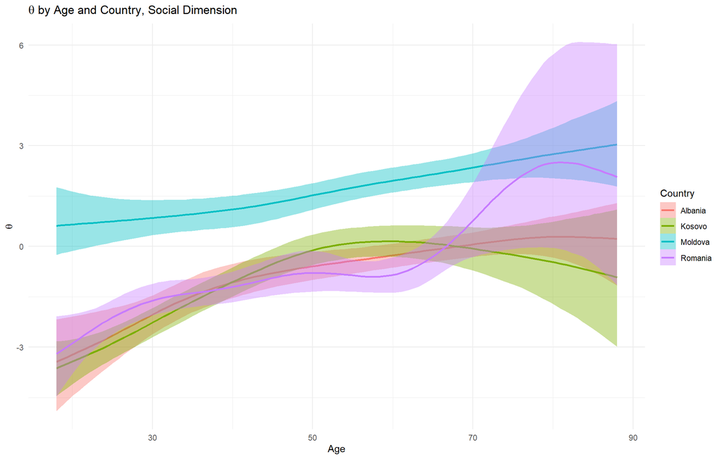

```r
print(plot9)
```

Personal dimension

```r
plot10 <- plot(
  conditional_effects(
    fit4,
    effects = "age:country",
    robust = TRUE
  ),
  plot = FALSE
)[[1]] +
  theme_minimal() +
  labs(
    title = expression(
      paste(theta, " by Age and Country, Personal Dimension")),
    x = "Age",
    y = expression(theta),
    color = "Country",
    fill = "Country"
  )

ggsave("plot10-theta-personal.pdf",
       plot = plot10, width = 9, height = 6)
```

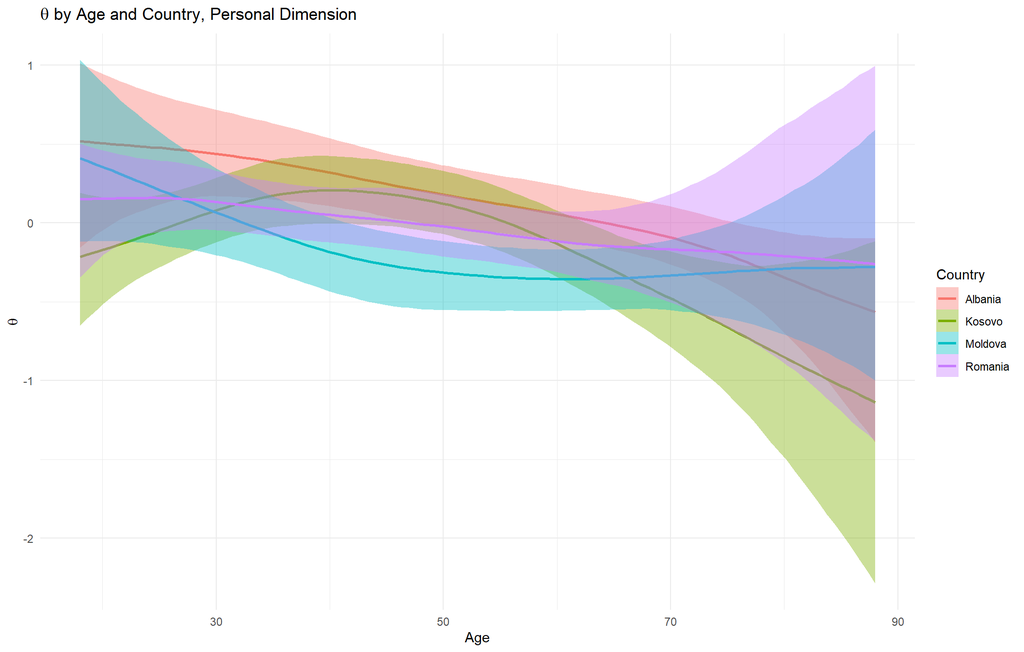

```r
print(plot10)
```

Environmental dimension

```r
plot11 <- plot(
  conditional_effects(
    fit5,
    effects = "age:country",
    robust = TRUE
  ),
  plot = FALSE
)[[1]] +
  theme_minimal() +
  labs(
    title = expression(
      paste(theta, " by Age and Country, Environmental Dimension")),
    x = "Age",
    y = expression(theta),
    color = "Country",
    fill = "Country"
  )

ggsave("plot11-theta-environmental.pdf",
       plot = plot11, width = 9, height = 6)
```

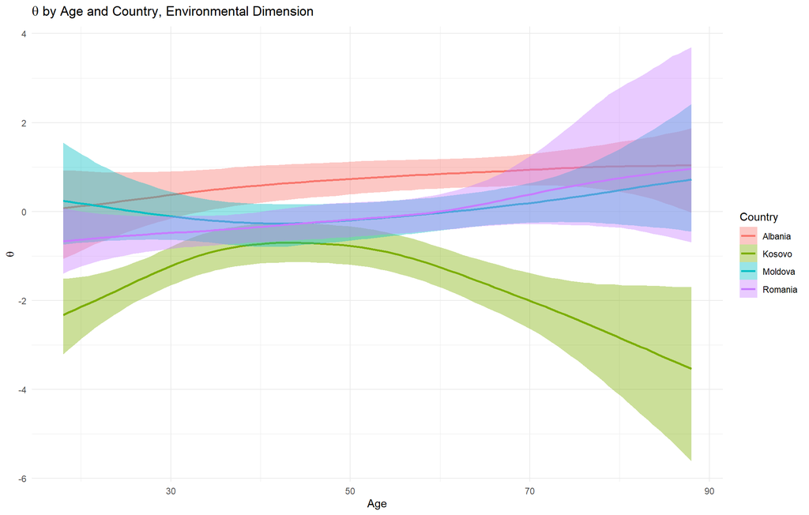

```r
print(plot11)
```